# BS_Behavioral

Another interesting behavior to look at would be swallowing - are the sharks sampling? Or are they merely swallowing? From observation, it seems like they don’t *always* continue feeding afterwards. Let’s look at where most of the swallowing happens as it compares to where the feeding tends to happen.

```r
# First need to set up the "straight swim" data
# top 25% water column
topswal <- topdat[topdat$Behavior=="Swallow",]
swal1<- nrow(topswal)/nrow(topdat)
swal1 #.05
```

```
## [1] 0.04971403
```

```r
# 25-50% water column
midtopswal <- midtopdat[midtopdat$Behavior=="Swallow",]
swal2<- nrow(midtopswal)/nrow(midtopdat)
swal2 #.04
```

```
## [1] 0.03257042
```

```r
lowtopswal <- lowtopdat[lowtopdat$Behavior=="Swallow",]
swal3<- nrow(lowtopswal)/nrow(lowtopdat)
swal3 #.007
```

```
## [1] 0.009234828
```

```r
lowswal <- lowdat[lowdat$Behavior=="Swallow",]
swal4<- nrow(lowswal)/nrow(lowdat)
swal4 #.002
```

```
## [1] 0.002639683
```

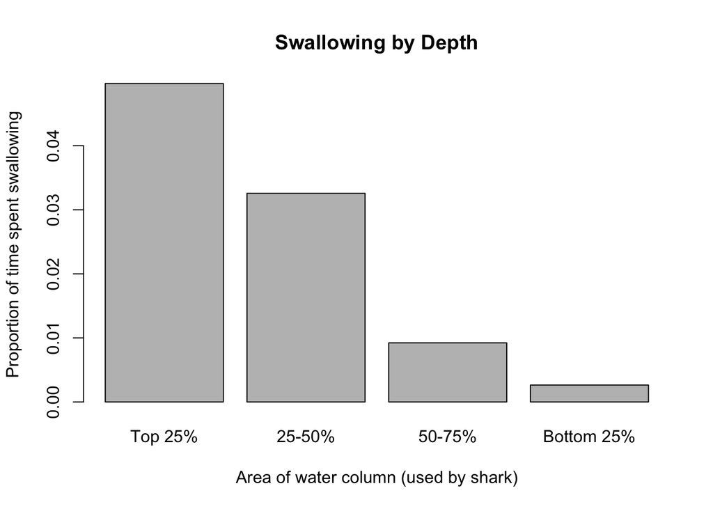

```r
# plotting the swallow data
swalgraph <- barplot(height=c(swal1, swal2, swal3,swal4), names.arg=(c("Top 25%", "25-50%", "50-75%", "Bottom 25%")), xlab="Area of water column (used by shark)", ylab="Proportion of time spent swallowing", main="Swallowing by Depth")
```

This is an instance where shark 2 differs from shark 3 - most swallowing occurs in the upper part of the water column

Now let’s put all the graphs together for ease of visualization.

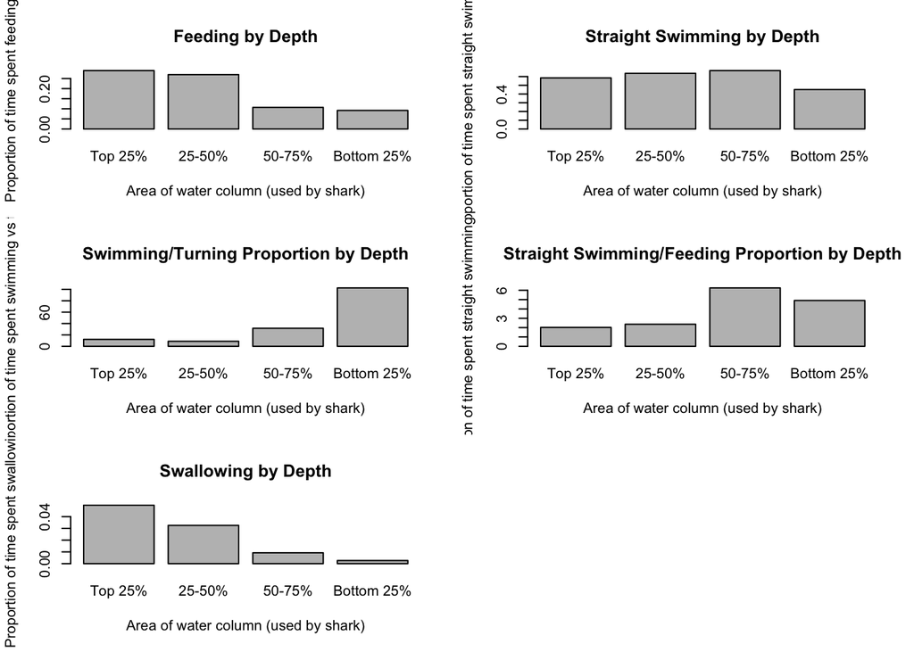

```r
par(mfrow=c(3,2))
barplot(height=c(feed1, feed2, feed3,feed4), names.arg=(c("Top 25%", "25-50%", "50-75%", "Bottom 25%")), xlab="Area of water column (used by shark)", ylab="Proportion of time spent feeding", main="Feeding by Depth")

barplot(height=c(swim1, swim2, swim3,swim4), names.arg=(c("Top 25%", "25-50%", "50-75%", "Bottom 25%")), xlab="Area of water column (used by shark)", ylab="Proportion of time spent straight swimming", main="Straight Swimming by Depth")

barplot(height=c(st1, st2, st3, st4), names.arg=(c("Top 25%", "25-50%", "50-75%", "Bottom 25%")), xlab="Area of water column (used by shark)", ylab="Proportion of time spent swimming vs turning", main="Swimming/Turning Proportion by Depth")

barplot(height=c(sf1, sf2, sf3, sf4), names.arg=(c("Top 25%", "25-50%", "50-75%", "Bottom 25%")), xlab="Area of water column (used by shark)", ylab="Proportion of time spent straight swimming vs feeding", main="Straight Swimming/Feeding Proportion by Depth")

barplot(height=c(swal1, swal2, swal3,swal4), names.arg=(c("Top 25%", "25-50%", "50-75%", "Bottom 25%")), xlab="Area of water column (used by shark)", ylab="Proportion of time spent swallowing", main="Swallowing by Depth")
```

Now let’s look at characteristics of each of these parts of the water column.

```r
summary(fulldat)
```

```
##     Pressure           Acc1            Acc2            Acc3
##  Min.   :-28073   Min.   :-6976   Min.   :-6944   Min.   : 208
##  1st Qu.:-27345   1st Qu.:-1648   1st Qu.:-3952   1st Qu.:3696
##  Median :-26504   Median :-1136   Median :-3152   Median :4128
##  Mean   :-19260   Mean   :-1099   Mean   :-2950   Mean   :4031
##  3rd Qu.: -9240   3rd Qu.: -576   3rd Qu.:-2256   3rd Qu.:4464
##  Max.   : 62946   Max.   : 4720   Max.   : 7312   Max.   :7936
##
##      Acc2.1          Acc2.2           Acc2.3          Light
##  Min.   :-9140   Min.   :-14608   Min.   : 5520   Min.   : 100
##  1st Qu.: 1303   1st Qu.:  4752   1st Qu.:12312   1st Qu.: 806
##  Median : 2406   Median :  6528   Median :13232   Median :3500
##  Mean   : 2306   Mean   :  6145   Mean   :13081   Mean   :2554
##  3rd Qu.: 3400   3rd Qu.:  8148   3rd Qu.:14008   3rd Qu.:3500
##  Max.   :14084   Max.   : 14296   Max.   :22204   Max.   :3500
##
##   Temperature         ODBA               chron
##  Min.   :15.06   Min.   :-2922.667   Min.   :19:21:38
##  1st Qu.:15.38   1st Qu.: -117.333   1st Qu.:20:10:48
##  Median :15.50   Median :    5.333   Median :20:53:43
##  Mean   :15.59   Mean   :   -0.218   Mean   :20:50:15
##  3rd Qu.:15.81   3rd Qu.:  122.667   3rd Qu.:21:32:54
##  Max.   :17.56   Max.   : 4160.000   Max.   :22:10:47
##
##               Behavior    comments          feeding
##  Straight swim    :5321   Mode:logical   Min.   :0.0000
##  Swim along bottom:1412   NA's:9092      1st Qu.:0.0000
##  Feed             :1177                  Median :0.0000
##  Rturn            : 448                  Mean   :0.1894
##  Swallow          : 214                  3rd Qu.:0.0000
##  Lturn            : 189                  Max.   :1.0000
##  (Other)          : 331
```

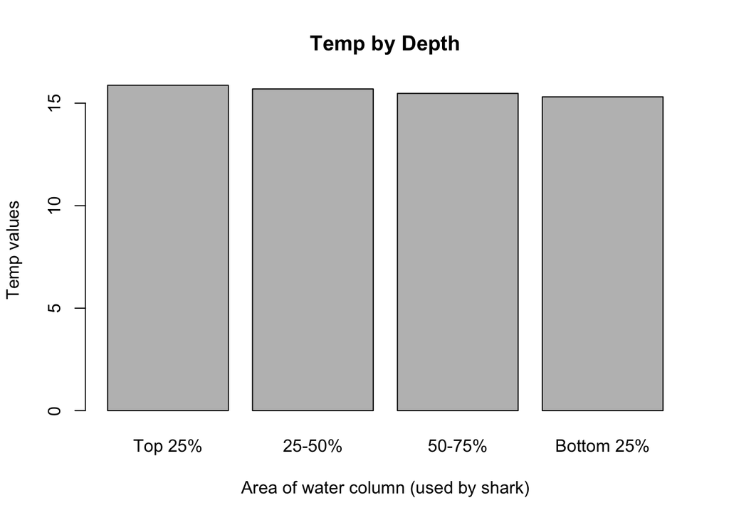

```r
barplot(height=c(mean(topdat$Temperature), mean(midtopdat$Temperature), mean(lowtopdat$Temperature), mean(lowdat$Temperature)), names.arg=(c("Top 25%", "25-50%", "50-75%", "Bottom 25%")), xlab="Area of water column (used by shark)", ylab="Temp values", main="Temp by Depth")
```

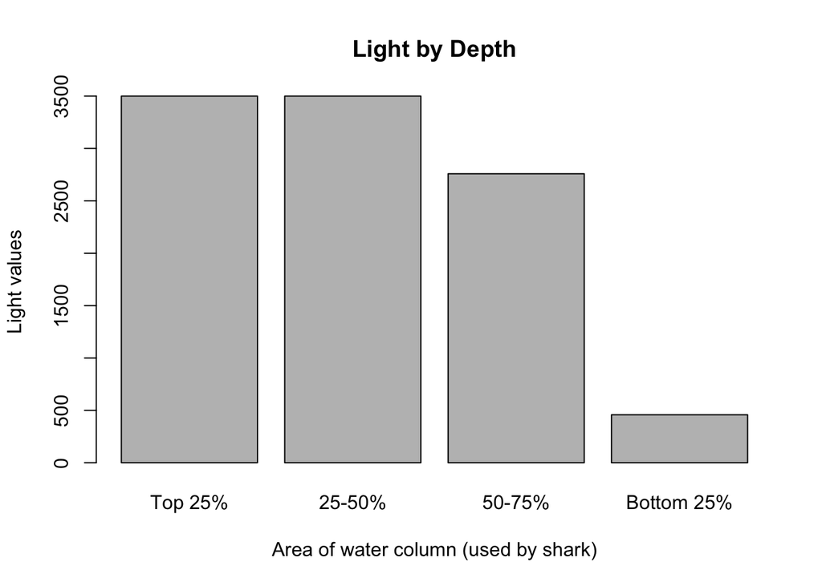

```r
#almost no change in mean temperature (water fully mixed) - same as with shark 3

barplot(height=c(mean(topdat$Light), mean(midtopdat$Light), mean(lowtopdat$Light), mean(lowdat$Light)), names.arg=(c("Top 25%", "25-50%", "50-75%", "Bottom 25%")), xlab="Area of water column (used by shark)", ylab="Light values", main="Light by Depth")
```

```r
# drops off drastically in the bottom quarter of the area used by the shark - same as shark 3
```

Summary here: for both sharks, don’t see a ton of environmental differences.

For shark 2, the accelerometer values are as of yet unclear. Still need to define the channels. But, we can look at ODBA:

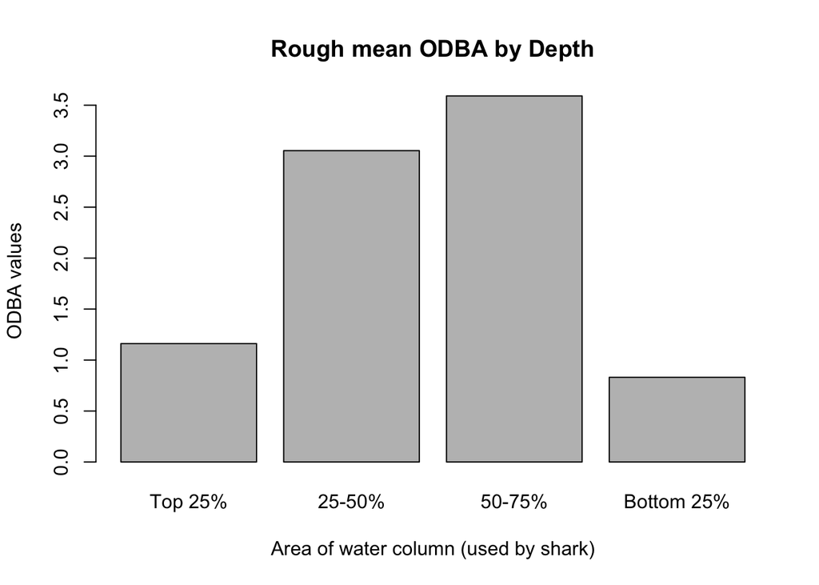

```r
barplot(height=c(abs(mean(topdat$ODBA)), abs(mean(midtopdat$ODBA)), abs(mean(lowtopdat$ODBA)), abs(mean(lowdat$ODBA))), names.arg=(c("Top 25%", "25-50%", "50-75%", "Bottom 25%")), xlab="Area of water column (used by shark)", ylab="ODBA values", main="Rough mean ODBA by Depth")
```

*Final notes on comparison so far -*

*Behavioral data*

- Feeding for both sharks declines with depth - most takes place in upper 50% of water column
- Straight swimming: shark 2 and 3 = mostly in 25-75% depth range (not sure if significant) **Swim/turn proportion highest in 50 - 75% for shark3, but is highest at depth in bottom 50% for shark 3** **Straight swimming/feeding proportion highest at bottom 25% of water column for shark 3, lower 50-75% for shark2** - Note that “straight swimming” refers to NO TURNS. “Swimming” refers to anything but feeding.
- Swallowing for shark 3 is most frequent in middle 25-75% depth range, but for shark 2, happens primarily in top 50%

*Environmental data* - For both sharks, water seems well mixed, and light level doesn’t drop off until the bottom 25%

*Accelerometer data* - Shark 3: Sway highest at surface 25% (looking at amplitude) - Rough mean ODBA by depth = highest at surface - Shark 2: Haven’t had a chance to convert accelerometer channel values yet - Rough mean ODBA here, however, was highest in middle 25-75% of water column